# Classification

### Best Result From Previous Study

93% PCC with Decision Tree - [Reference](http://www3.dsi.uminho.pt/pcortez/student.pdf)

### Imports

```r
library(dplyr)
library(ggplot2)
library(caret)
```

### Preparation

```r
df <- read.csv("../data/student-por_v3.csv", stringsAsFactors = TRUE)
head(df)
```

|  | school | sex | age | address | famsize | Pstatus | Medu | Fedu | Mjob | Fjob | reason | guardian | traveltime | studytime | failures | schoolsup | famsup | paid | activities | nursery | higher | internet | romantic | famrel | freetime | goout | Dalc | Walc | health | … |
| --- | --- | --- | --- | --- | --- | --- | --- | --- | --- | --- | --- | --- | --- | --- | --- | --- | --- | --- | --- | --- | --- | --- | --- | --- | --- | --- | --- | --- | --- | --- |
| 1 | GP | F | 18 | U | GT3 | A | 4 | 4 | at_home | teacher | course | mother | 2 | 2 | 0 | yes | no | no | no | yes | yes | no | no | 4 | 3 | 4 | 1 | 1 | 3 | … |
| 2 | GP | F | 17 | U | GT3 | T | 1 | 1 | at_home | other | course | father | 1 | 2 | 0 | no | yes | no | no | no | yes | yes | no | 5 | 3 | 3 | 1 | 1 | 3 | … |
| 3 | GP | F | 15 | U | LE3 | T | 1 | 1 | at_home | other | other | mother | 1 | 2 | 0 | yes | no | no | no | yes | yes | yes | no | 4 | 3 | 2 | 2 | 3 | 3 | … |
| 4 | GP | F | 15 | U | GT3 | T | 4 | 2 | health | services | home | mother | 1 | 3 | 0 | no | yes | no | yes | yes | yes | yes | yes | 3 | 2 | 2 | 1 | 1 | 5 | … |
| 5 | GP | F | 16 | U | GT3 | T | 3 | 3 | other | other | home | father | 1 | 2 | 0 | no | yes | no | no | yes | yes | no | no | 4 | 3 | 2 | 1 | 2 | 5 | … |
| 6 | GP | M | 16 | U | LE3 | T | 4 | 3 | services | other | reputation | mother | 1 | 2 | 0 | no | yes | no | yes | yes | yes | yes | no | 5 | 4 | 2 | 1 | 2 | 5 | … |

```r
str(df)
```

```
'data.frame':   649 obs. of  34 variables:
 $ school    : Factor w/ 2 levels "GP","MS": 1 1 1 1 1 1 1 1 1 1 ...
 $ sex       : Factor w/ 2 levels "F","M": 1 1 1 1 1 2 2 1 2 2 ...
 $ age       : int  18 17 15 15 16 16 16 17 15 15 ...
 $ address   : Factor w/ 2 levels "R","U": 2 2 2 2 2 2 2 2 2 2 ...
 $ famsize   : Factor w/ 2 levels "GT3","LE3": 1 1 2 1 1 2 2 1 2 1 ...
 $ Pstatus   : Factor w/ 2 levels "A","T": 1 2 2 2 2 2 2 1 1 2 ...
 $ Medu      : int  4 1 1 4 3 4 2 4 3 3 ...
 $ Fedu      : int  4 1 1 2 3 3 2 4 2 4 ...
 $ Mjob      : Factor w/ 5 levels "at_home","health",..: 1 1 1 2 3 4 3 3 4 3 ...
 $ Fjob      : Factor w/ 5 levels "at_home","health",..: 5 3 3 4 3 3 3 5 3 3 ...
 $ reason    : Factor w/ 4 levels "course","home",..: 1 1 3 2 2 4 2 2 2 2 ...
 $ guardian  : Factor w/ 3 levels "father","mother",..: 2 1 2 2 1 2 2 2 2 2 ...
 $ traveltime: int  2 1 1 1 1 1 1 2 1 1 ...
 $ studytime : int  2 2 2 3 2 2 2 2 2 2 ...
```

[output cut: 20 more lines]

```r
summary(df)
```

```
 school   sex          age        address famsize   Pstatus      Medu
 GP:423   F:383   Min.   :15.00   R:197   GT3:457   A: 80   Min.   :0.000
 MS:226   M:266   1st Qu.:16.00   U:452   LE3:192   T:569   1st Qu.:2.000
                  Median :17.00                             Median :2.000
                  Mean   :16.74                             Mean   :2.515
                  3rd Qu.:18.00                             3rd Qu.:4.000
                  Max.   :22.00                             Max.   :4.000
      Fedu             Mjob           Fjob            reason      guardian
 Min.   :0.000   at_home :135   at_home : 42   course    :285   father:153
 1st Qu.:1.000   health  : 48   health  : 23   home      :149   mother:455
 Median :2.000   other   :258   other   :367   other     : 72   other : 41
 Mean   :2.307   services:136   services:181   reputation:143
 3rd Qu.:3.000   teacher : 72   teacher : 36
 Max.   :4.000
   traveltime      studytime        failures      schoolsup famsup     paid
 Min.   :1.000   Min.   :1.000   Min.   :0.0000   no :581   no :251   no :610
 1st Qu.:1.000   1st Qu.:1.000   1st Qu.:0.0000   yes: 68   yes:398   yes: 39
 Median :1.000   Median :2.000   Median :0.0000
 Mean   :1.569   Mean   :1.931   Mean   :0.2219
 3rd Qu.:2.000   3rd Qu.:2.000   3rd Qu.:0.0000
 Max.   :4.000   Max.   :4.000   Max.   :3.0000
 activities nursery   higher    internet  romantic      famrel
 no :334    no :128   no : 69   no :151   no :410   Min.   :1.000
 yes:315    yes:521   yes:580   yes:498   yes:239   1st Qu.:4.000
                                                    Median :4.000
                                                    Mean   :3.931
                                                    3rd Qu.:5.000
                                                    Max.   :5.000
    freetime        goout            Dalc            Walc          health
 Min.   :1.00   Min.   :1.000   Min.   :1.000   Min.   :1.00   Min.   :1.000
 1st Qu.:3.00   1st Qu.:2.000   1st Qu.:1.000   1st Qu.:1.00   1st Qu.:2.000
 Median :3.00   Median :3.000   Median :1.000   Median :2.00   Median :4.000
 Mean   :3.18   Mean   :3.185   Mean   :1.502   Mean   :2.28   Mean   :3.536
 3rd Qu.:4.00   3rd Qu.:4.000   3rd Qu.:2.000   3rd Qu.:3.00   3rd Qu.:5.000
 Max.   :5.00   Max.   :5.000   Max.   :5.000   Max.   :5.00   Max.   :5.000
    absences            G1             G2              G3         result
 Min.   : 0.000   Min.   : 0.0   Min.   : 0.00   Min.   : 0.00   fail:100
 1st Qu.: 0.000   1st Qu.:10.0   1st Qu.:10.00   1st Qu.:10.00   pass:549
 Median : 2.000   Median :11.0   Median :11.00   Median :12.00
 Mean   : 3.659   Mean   :11.4   Mean   :11.57   Mean   :11.91
 3rd Qu.: 6.000   3rd Qu.:13.0   3rd Qu.:13.00   3rd Qu.:14.00
 Max.   :32.000   Max.   :19.0   Max.   :19.00   Max.   :19.00
```

Convert ordinal variables into ordered factors.

```r
df$famsize <- factor(df$famsize, ordered = TRUE, levels = c("LE3", "GT3"))
df$Medu <- factor(df$Medu, ordered = TRUE, levels = 0:4)
df$Fedu <- factor(df$Fedu, ordered = TRUE, levels = 0:4)
df$traveltime <- factor(df$traveltime, ordered = TRUE, levels = 1:4)
df$studytime <- factor(df$studytime, ordered = TRUE, levels = 1:4)
df$failures <- factor(df$failures, ordered = TRUE, levels = 0:4)
df$famrel <- factor(df$famrel, ordered = TRUE, levels = 1:5)
df$freetime <- factor(df$freetime, ordered = TRUE, levels = 1:5)
df$goout <- factor(df$goout, ordered = TRUE, levels = 1:5)
df$Dalc <- factor(df$Dalc, ordered = TRUE, levels = 1:5)
df$Walc <- factor(df$Walc, ordered = TRUE, levels = 1:5)
df$health <- factor(df$health, ordered = TRUE, levels = 1:5)
```

Drop `G3` column as `G3` will be used for regression.

```r
df$G3 <- NULL
```

```r
str(df)
```

```
'data.frame':   649 obs. of  33 variables:
 $ school    : Factor w/ 2 levels "GP","MS": 1 1 1 1 1 1 1 1 1 1 ...
 $ sex       : Factor w/ 2 levels "F","M": 1 1 1 1 1 2 2 1 2 2 ...
 $ age       : int  18 17 15 15 16 16 16 17 15 15 ...
 $ address   : Factor w/ 2 levels "R","U": 2 2 2 2 2 2 2 2 2 2 ...
 $ famsize   : Ord.factor w/ 2 levels "LE3"<"GT3": 2 2 1 2 2 1 1 2 1 2 ...
 $ Pstatus   : Factor w/ 2 levels "A","T": 1 2 2 2 2 2 2 1 1 2 ...
 $ Medu      : Ord.factor w/ 5 levels "0"<"1"<"2"<"3"<..: 5 2 2 5 4 5 3 5 4 4 ...
 $ Fedu      : Ord.factor w/ 5 levels "0"<"1"<"2"<"3"<..: 5 2 2 3 4 4 3 5 3 5 ...
 $ Mjob      : Factor w/ 5 levels "at_home","health",..: 1 1 1 2 3 4 3 3 4 3 ...
 $ Fjob      : Factor w/ 5 levels "at_home","health",..: 5 3 3 4 3 3 3 5 3 3 ...
 $ reason    : Factor w/ 4 levels "course","home",..: 1 1 3 2 2 4 2 2 2 2 ...
 $ guardian  : Factor w/ 3 levels "father","mother",..: 2 1 2 2 1 2 2 2 2 2 ...
 $ traveltime: Ord.factor w/ 4 levels "1"<"2"<"3"<"4": 2 1 1 1 1 1 1 2 1 1 ...
 $ studytime : Ord.factor w/ 4 levels "1"<"2"<"3"<"4": 2 2 2 3 2 2 2 2 2 2 ...
```

[output cut: 19 more lines]

```r
summary(df)
```

```
 school   sex          age        address famsize   Pstatus Medu    Fedu
 GP:423   F:383   Min.   :15.00   R:197   LE3:192   A: 80   0:  6   0:  7
 MS:226   M:266   1st Qu.:16.00   U:452   GT3:457   T:569   1:143   1:174
                  Median :17.00                             2:186   2:209
                  Mean   :16.74                             3:139   3:131
                  3rd Qu.:18.00                             4:175   4:128
                  Max.   :22.00
       Mjob           Fjob            reason      guardian   traveltime
 at_home :135   at_home : 42   course    :285   father:153   1:366
 health  : 48   health  : 23   home      :149   mother:455   2:213
 other   :258   other   :367   other     : 72   other : 41   3: 54
 services:136   services:181   reputation:143                4: 16
 teacher : 72   teacher : 36

 studytime failures schoolsup famsup     paid     activities nursery   higher
 1:212     0:549    no :581   no :251   no :610   no :334    no :128   no : 69
 2:305     1: 70    yes: 68   yes:398   yes: 39   yes:315    yes:521   yes:580
 3: 97     2: 16
 4: 35     3: 14
           4:  0

 internet  romantic  famrel  freetime goout   Dalc    Walc    health
 no :151   no :410   1: 22   1: 45    1: 48   1:451   1:247   1: 90
 yes:498   yes:239   2: 29   2:107    2:145   2:121   2:150   2: 78
                     3:101   3:251    3:205   3: 43   3:120   3:124
                     4:317   4:178    4:141   4: 17   4: 87   4:108
                     5:180   5: 68    5:110   5: 17   5: 45   5:249

    absences            G1             G2         result
 Min.   : 0.000   Min.   : 0.0   Min.   : 0.00   fail:100
 1st Qu.: 0.000   1st Qu.:10.0   1st Qu.:10.00   pass:549
 Median : 2.000   Median :11.0   Median :11.00
 Mean   : 3.659   Mean   :11.4   Mean   :11.57
 3rd Qu.: 6.000   3rd Qu.:13.0   3rd Qu.:13.00
 Max.   :32.000   Max.   :19.0   Max.   :19.00
```

### Train-Test Split

```r
set.seed(42)

train_index <- createDataPartition(
  df$result,
  p = 0.8,
  list = FALSE,
  times = 1
)

train_set <- df[train_index, ]
test_set <- df[-train_index, ]
```

```r
nrow(train_set)
```

```
[1] 520
```

```r
nrow(test_set)
```

```
[1] 129
```

### Subsampling

Check original classes.

```r
table(train_set$result)
```

```
fail pass
  80  440
```

Create sample using down-sampling.

```r
set.seed(42)

down_train_set <- downSample(
  x = train_set[, -ncol(train_set)],
  y = train_set$result,
  yname = "result"
)

table(down_train_set$result)
```

```
fail pass
  80   80
```

Create sample using up-sampling.

```r
set.seed(42)

up_train_set <- upSample(
  x = train_set[, -ncol(train_set)],
  y = train_set$result,
  yname = "result"
)

table(up_train_set$result)
```

```
fail pass
 440  440
```

### Modeling

Define repeated 10-fold cross validation.

```r
fit_control <- trainControl(
  method = "repeatedcv",
  number = 10,
  repeats = 10
)
```

Define a helper function to train model.

```r
train_model <- function(method = "",
                        data = train_set,
                        tuneGrid = NULL,
                        tuneLength = 3) {
  set.seed(42)

  fit <- train(
    result ~ .,
    data = data,
    method = method,
    trControl = fit_control,
    preProcess = c("center", "scale"),
    tuneGrid = tuneGrid,
    tuneLength = tuneLength
  )

  print(fit)

  return(fit)
}
```

Define a helper function to evaluate model.

```r
evaluate_model <- function(model = NULL, alias = "", family = "") {
  pred <- predict(model, test_set)

  cm <- confusionMatrix(pred, test_set$result, mode = "prec_recall")
  print(cm)

  precision_score <- precision(pred, test_set$result)
  recall_score <- recall(pred, test_set$result)
  f1_score <- F_meas(pred, test_set$result)

  return(data.frame(
    Model = alias,
    Family = ifelse(family == "", alias, family),
    Accuracy = round(cm$overall[["Accuracy"]], 3),
    Precision = round(precision_score, 3),
    Recall = round(recall_score, 3),
    F1 = round(f1_score, 3)
  ))
}
```

#### Decision Tree

##### Original Train Set

```r
dt_clf <- train_model("rpart2")
```

```
note: only 2 possible values of the max tree depth from the initial fit.
 Truncating the grid to 2 .

CART

520 samples
 32 predictor
  2 classes: 'fail', 'pass'

Pre-processing: centered (72), scaled (72)
Resampling: Cross-Validated (10 fold, repeated 10 times)
Summary of sample sizes: 468, 468, 468, 468, 468, 468, ...
Resampling results across tuning parameters:

  maxdepth  Accuracy   Kappa
  1         0.9365385  0.7199437
  4         0.9286538  0.7122307

Accuracy was used to select the optimal model using the largest value.
The final value used for the model was maxdepth = 1.
```

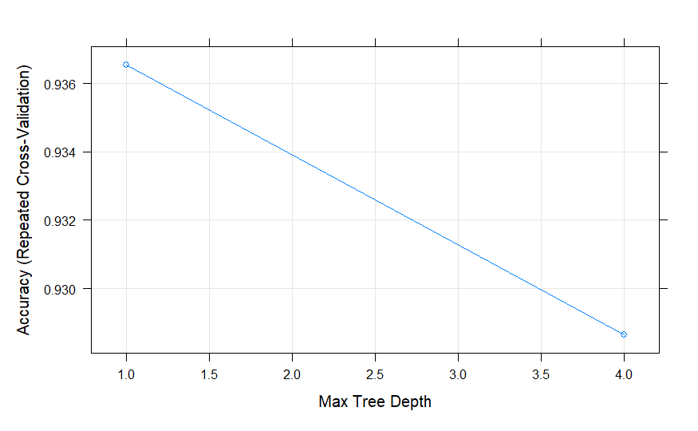

```r
plot(dt_clf)
```

No further tuning required.

```r
dt_metrics <- evaluate_model(dt_clf, "DT")
```

```
Confusion Matrix and Statistics

          Reference
Prediction fail pass
      fail   13    1
      pass    7  108

               Accuracy : 0.938
                 95% CI : (0.8815, 0.9728)
    No Information Rate : 0.845
    P-Value [Acc > NIR] : 0.001075

                  Kappa : 0.7303

 Mcnemar's Test P-Value : 0.077100

              Precision : 0.9286
                 Recall : 0.6500
                     F1 : 0.7647
             Prevalence : 0.1550
         Detection Rate : 0.1008
   Detection Prevalence : 0.1085
      Balanced Accuracy : 0.8204

       'Positive' Class : fail
```

##### Down-Sampled Train Set

```r
down_dt_clf <- train_model("rpart2", down_train_set)
```

```
note: only 2 possible values of the max tree depth from the initial fit.
 Truncating the grid to 2 .

CART

160 samples
 32 predictor
  2 classes: 'fail', 'pass'

Pre-processing: centered (72), scaled (72)
Resampling: Cross-Validated (10 fold, repeated 10 times)
Summary of sample sizes: 144, 144, 144, 144, 144, 144, ...
Resampling results across tuning parameters:

  maxdepth  Accuracy  Kappa
  1         0.838125  0.67625
  2         0.823750  0.64750

Accuracy was used to select the optimal model using the largest value.
The final value used for the model was maxdepth = 1.
```

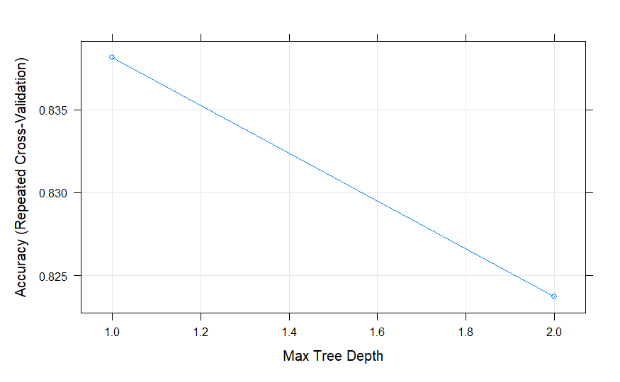

```r
plot(down_dt_clf)
```

No further tuning required.

```r
down_dt_metrics <- evaluate_model(down_dt_clf, "DT")
```

```
Confusion Matrix and Statistics

          Reference
Prediction fail pass
      fail   17   15
      pass    3   94

               Accuracy : 0.8605
                 95% CI : (0.7885, 0.9152)
    No Information Rate : 0.845
    P-Value [Acc > NIR] : 0.366920

                  Kappa : 0.5722

 Mcnemar's Test P-Value : 0.009522

              Precision : 0.5312
                 Recall : 0.8500
                     F1 : 0.6538
             Prevalence : 0.1550
         Detection Rate : 0.1318
   Detection Prevalence : 0.2481
      Balanced Accuracy : 0.8562

       'Positive' Class : fail
```

##### Up-Sampled Train Set

```r
up_dt_clf <- train_model("rpart2", up_train_set)
```

```
CART

880 samples
 32 predictor
  2 classes: 'fail', 'pass'

Pre-processing: centered (72), scaled (72)
Resampling: Cross-Validated (10 fold, repeated 10 times)
Summary of sample sizes: 792, 792, 792, 792, 792, 792, ...
Resampling results across tuning parameters:

  maxdepth  Accuracy   Kappa
  1         0.8892045  0.7784091
  3         0.9173864  0.8347727
  4         0.9296591  0.8593182

Accuracy was used to select the optimal model using the largest value.
The final value used for the model was maxdepth = 4.
```

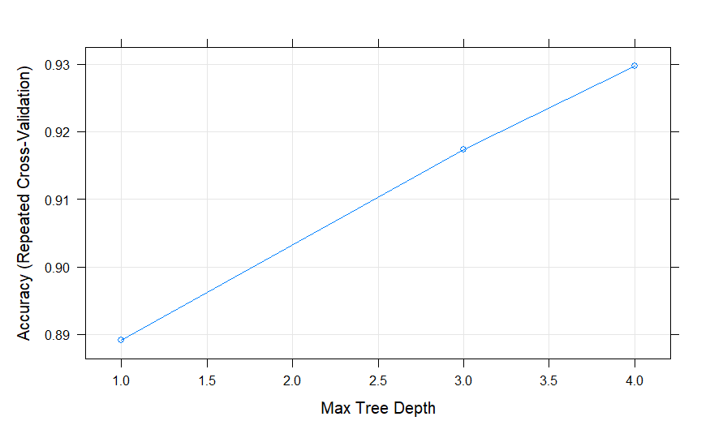

```r
plot(up_dt_clf)
```

Perform hyperparameter tuning using `tuneLength`.

```r
up_dt_clf <- train_model("rpart2", up_train_set, tuneLength = 10)
```

```
note: only 7 possible values of the max tree depth from the initial fit.
 Truncating the grid to 7 .

CART

880 samples
 32 predictor
  2 classes: 'fail', 'pass'

Pre-processing: centered (72), scaled (72)
Resampling: Cross-Validated (10 fold, repeated 10 times)
Summary of sample sizes: 792, 792, 792, 792, 792, 792, ...
Resampling results across tuning parameters:

  maxdepth  Accuracy   Kappa
   1        0.8892045  0.7784091
   3        0.9173864  0.8347727
   4        0.9238636  0.8477273
   7        0.9294318  0.8588636
   8        0.9294318  0.8588636
  11        0.9294318  0.8588636
  12        0.9294318  0.8588636

Accuracy was used to select the optimal model using the largest value.
The final value used for the model was maxdepth = 7.
```

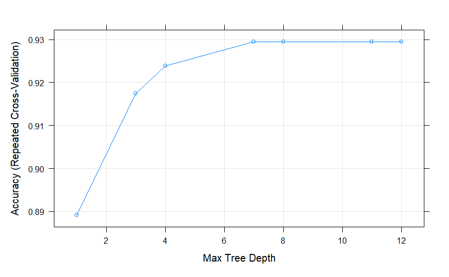

```r
plot(up_dt_clf)
```

Tuning done.

```r
up_dt_metrics <- evaluate_model(up_dt_clf, "DT")
```

```
Confusion Matrix and Statistics

          Reference
Prediction fail pass
      fail   16   11
      pass    4   98

               Accuracy : 0.8837
                 95% CI : (0.8155, 0.9334)
    No Information Rate : 0.845
    P-Value [Acc > NIR] : 0.1352

                  Kappa : 0.6117

 Mcnemar's Test P-Value : 0.1213

              Precision : 0.5926
                 Recall : 0.8000
                     F1 : 0.6809
             Prevalence : 0.1550
         Detection Rate : 0.1240
   Detection Prevalence : 0.2093
      Balanced Accuracy : 0.8495

       'Positive' Class : fail
```

#### Random Forest

##### Original Train Set

```r
rf_clf <- train_model("ranger")
```

```
Random Forest

520 samples
 32 predictor
  2 classes: 'fail', 'pass'

Pre-processing: centered (72), scaled (72)
Resampling: Cross-Validated (10 fold, repeated 10 times)
Summary of sample sizes: 468, 468, 468, 468, 468, 468, ...
Resampling results across tuning parameters:

  mtry  splitrule   Accuracy   Kappa
   2    gini        0.8744231  0.2633357
   2    extratrees  0.8594231  0.1295123
  37    gini        0.9307692  0.7051503
  37    extratrees  0.9275000  0.6794896
  72    gini        0.9313462  0.7069938
  72    extratrees  0.9350000  0.7230234

Tuning parameter 'min.node.size' was held constant at a value of 1
Accuracy was used to select the optimal model using the largest value.
The final values used for the model were mtry = 72, splitrule = extratrees
 and min.node.size = 1.
```

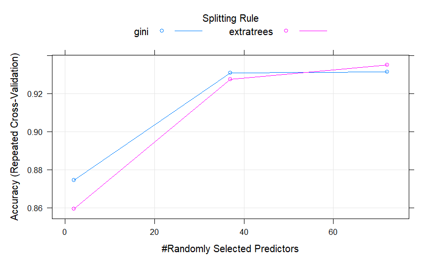

```r
plot(rf_clf)
```

Perform hyperparameter tuning using `tuneLength`.

```r
rf_clf <- train_model("ranger", tuneLength = 7)
```

```
Random Forest

520 samples
 32 predictor
  2 classes: 'fail', 'pass'

Pre-processing: centered (72), scaled (72)
Resampling: Cross-Validated (10 fold, repeated 10 times)
Summary of sample sizes: 468, 468, 468, 468, 468, 468, ...
Resampling results across tuning parameters:

  mtry  splitrule   Accuracy   Kappa
   2    gini        0.8753846  0.2723578
   2    extratrees  0.8582692  0.1202263
  13    gini        0.9336538  0.7118338
  13    extratrees  0.9017308  0.5067021
  25    gini        0.9311538  0.7082097
  25    extratrees  0.9217308  0.6373321
  37    gini        0.9313462  0.7085045
  37    extratrees  0.9257692  0.6709289
  48    gini        0.9296154  0.7010125
  48    extratrees  0.9300000  0.6973189
  60    gini        0.9315385  0.7095738
  60    extratrees  0.9351923  0.7227439
  72    gini        0.9311538  0.7077921
  72    extratrees  0.9344231  0.7236122

Tuning parameter 'min.node.size' was held constant at a value of 1
Accuracy was used to select the optimal model using the largest value.
The final values used for the model were mtry = 60, splitrule = extratrees
 and min.node.size = 1.
```

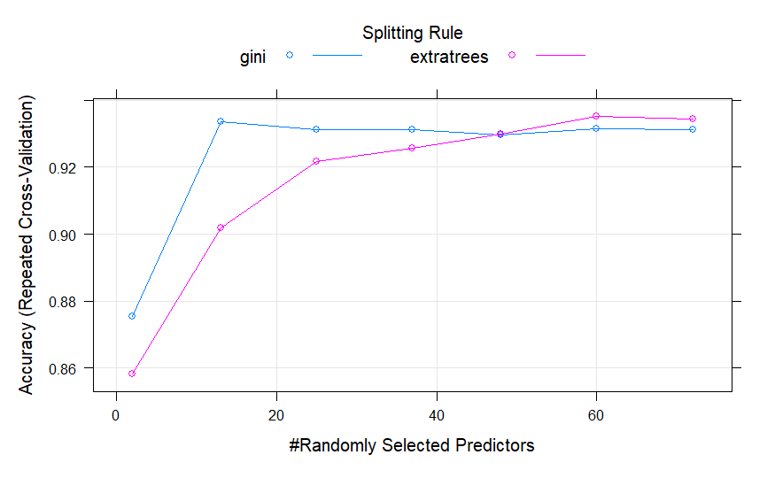

```r
plot(rf_clf)
```

Tuning done.

```r
rf_metrics <- evaluate_model(rf_clf, "RF")
```

```
Confusion Matrix and Statistics

          Reference
Prediction fail pass
      fail   14    4
      pass    6  105

               Accuracy : 0.9225
                 95% CI : (0.8621, 0.9622)
    No Information Rate : 0.845
    P-Value [Acc > NIR] : 0.006716

                  Kappa : 0.6915

 Mcnemar's Test P-Value : 0.751830

              Precision : 0.7778
                 Recall : 0.7000
                     F1 : 0.7368
             Prevalence : 0.1550
         Detection Rate : 0.1085
   Detection Prevalence : 0.1395
      Balanced Accuracy : 0.8317

       'Positive' Class : fail
```

##### Down-Sampled Train Set

```r
down_rf_clf <- train_model("ranger", down_train_set)
```

```
Random Forest

160 samples
 32 predictor
  2 classes: 'fail', 'pass'

Pre-processing: centered (72), scaled (72)
Resampling: Cross-Validated (10 fold, repeated 10 times)
Summary of sample sizes: 144, 144, 144, 144, 144, 144, ...
Resampling results across tuning parameters:

  mtry  splitrule   Accuracy  Kappa
   2    gini        0.795625  0.59125
   2    extratrees  0.757500  0.51500
  37    gini        0.879375  0.75875
  37    extratrees  0.846875  0.69375
  72    gini        0.880000  0.76000
  72    extratrees  0.868125  0.73625

Tuning parameter 'min.node.size' was held constant at a value of 1
Accuracy was used to select the optimal model using the largest value.
The final values used for the model were mtry = 72, splitrule = gini
 and min.node.size = 1.
```

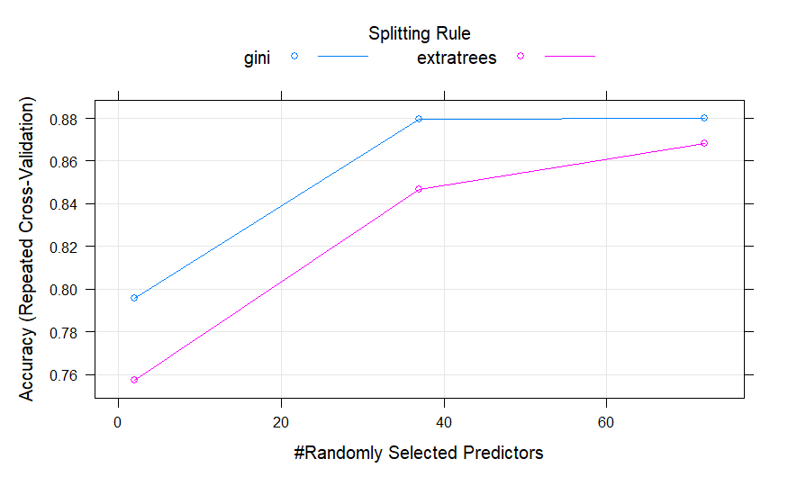

```r
plot(down_rf_clf)
```

Perform hyperparameter tuning using `tuneLength`.

```r
down_rf_clf <- train_model("ranger", down_train_set, tuneLength = 7)
```

```
Random Forest

160 samples
 32 predictor
  2 classes: 'fail', 'pass'

Pre-processing: centered (72), scaled (72)
Resampling: Cross-Validated (10 fold, repeated 10 times)
Summary of sample sizes: 144, 144, 144, 144, 144, 144, ...
Resampling results across tuning parameters:

  mtry  splitrule   Accuracy  Kappa
   2    gini        0.801875  0.60375
   2    extratrees  0.746875  0.49375
  13    gini        0.876250  0.75250
  13    extratrees  0.814375  0.62875
  25    gini        0.891250  0.78250
  25    extratrees  0.843750  0.68750
  37    gini        0.886250  0.77250
  37    extratrees  0.853750  0.70750
  48    gini        0.880000  0.76000
  48    extratrees  0.854375  0.70875
  60    gini        0.881875  0.76375
  60    extratrees  0.869375  0.73875
  72    gini        0.879375  0.75875
  72    extratrees  0.873125  0.74625

Tuning parameter 'min.node.size' was held constant at a value of 1
Accuracy was used to select the optimal model using the largest value.
The final values used for the model were mtry = 25, splitrule = gini
 and min.node.size = 1.
```

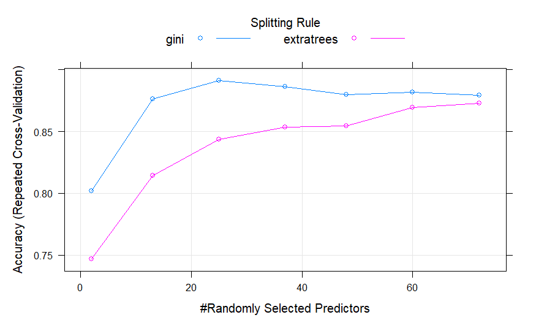

```r
plot(down_rf_clf)
```

Tuning done.

```r
down_rf_metrics <- evaluate_model(down_rf_clf, "RF")
```

```
Confusion Matrix and Statistics

          Reference
Prediction fail pass
      fail   17   13
      pass    3   96

               Accuracy : 0.876
                 95% CI : (0.8064, 0.9274)
    No Information Rate : 0.845
    P-Value [Acc > NIR] : 0.19935

                  Kappa : 0.6069

 Mcnemar's Test P-Value : 0.02445

              Precision : 0.5667
                 Recall : 0.8500
                     F1 : 0.6800
             Prevalence : 0.1550
         Detection Rate : 0.1318
   Detection Prevalence : 0.2326
      Balanced Accuracy : 0.8654

       'Positive' Class : fail
```

##### Up-Sampled Train Set

```r
up_rf_clf <- train_model("ranger", up_train_set)
```

```
Random Forest

880 samples
 32 predictor
  2 classes: 'fail', 'pass'

Pre-processing: centered (72), scaled (72)
Resampling: Cross-Validated (10 fold, repeated 10 times)
Summary of sample sizes: 792, 792, 792, 792, 792, 792, ...
Resampling results across tuning parameters:

  mtry  splitrule   Accuracy   Kappa
   2    gini        0.9803409  0.9606818
   2    extratrees  0.9795455  0.9590909
  37    gini        0.9789773  0.9579545
  37    extratrees  0.9820455  0.9640909
  72    gini        0.9786364  0.9572727
  72    extratrees  0.9786364  0.9572727

Tuning parameter 'min.node.size' was held constant at a value of 1
Accuracy was used to select the optimal model using the largest value.
The final values used for the model were mtry = 37, splitrule = extratrees
 and min.node.size = 1.
```

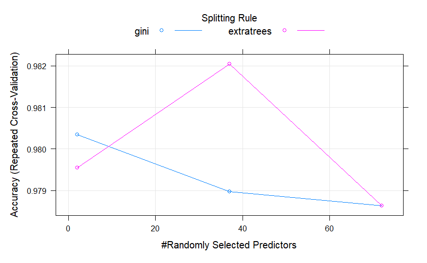

```r
plot(up_rf_clf)
```

Perform hyperparameter tuning using `tuneLength`.

```r
up_rf_clf <- train_model("ranger", up_train_set, tuneLength = 7)
```

```
Random Forest

880 samples
 32 predictor
  2 classes: 'fail', 'pass'

Pre-processing: centered (72), scaled (72)
Resampling: Cross-Validated (10 fold, repeated 10 times)
Summary of sample sizes: 792, 792, 792, 792, 792, 792, ...
Resampling results across tuning parameters:

  mtry  splitrule   Accuracy   Kappa
   2    gini        0.9812500  0.9625000
   2    extratrees  0.9801136  0.9602273
  13    gini        0.9807955  0.9615909
  13    extratrees  0.9819318  0.9638636
  25    gini        0.9794318  0.9588636
  25    extratrees  0.9802273  0.9604545
  37    gini        0.9785227  0.9570455
  37    extratrees  0.9815909  0.9631818
  48    gini        0.9786364  0.9572727
  48    extratrees  0.9817045  0.9634091
  60    gini        0.9787500  0.9575000
  60    extratrees  0.9803409  0.9606818
  72    gini        0.9781818  0.9563636
  72    extratrees  0.9780682  0.9561364

Tuning parameter 'min.node.size' was held constant at a value of 1
Accuracy was used to select the optimal model using the largest value.
The final values used for the model were mtry = 13, splitrule = extratrees
 and min.node.size = 1.
```

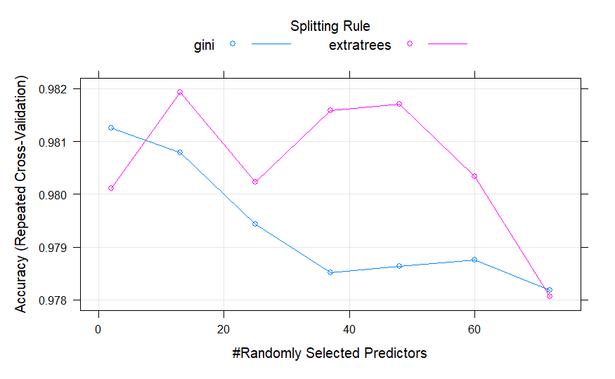

```r
plot(up_rf_clf)
```

Tuning done.

```r
up_rf_metrics <- evaluate_model(up_rf_clf, "RF")
```

```
Confusion Matrix and Statistics

          Reference
Prediction fail pass
      fail   12    3
      pass    8  106

               Accuracy : 0.9147
                 95% CI : (0.8525, 0.9567)
    No Information Rate : 0.845
    P-Value [Acc > NIR] : 0.01442

                  Kappa : 0.6375

 Mcnemar's Test P-Value : 0.22780

              Precision : 0.80000
                 Recall : 0.60000
                     F1 : 0.68571
             Prevalence : 0.15504
         Detection Rate : 0.09302
   Detection Prevalence : 0.11628
      Balanced Accuracy : 0.78624

       'Positive' Class : fail
```

#### Support Vector Machine (Linear Kernel)

##### Original Train Set

```r
svm_lin_clf <- train_model("svmLinear2")
```

```
Support Vector Machines with Linear Kernel

520 samples
 32 predictor
  2 classes: 'fail', 'pass'

Pre-processing: centered (72), scaled (72)
Resampling: Cross-Validated (10 fold, repeated 10 times)
Summary of sample sizes: 468, 468, 468, 468, 468, 468, ...
Resampling results across tuning parameters:

  cost  Accuracy   Kappa
  0.25  0.9088462  0.6400712
  0.50  0.9057692  0.6324726
  1.00  0.9059615  0.6393319

Accuracy was used to select the optimal model using the largest value.
The final value used for the model was cost = 0.25.
```

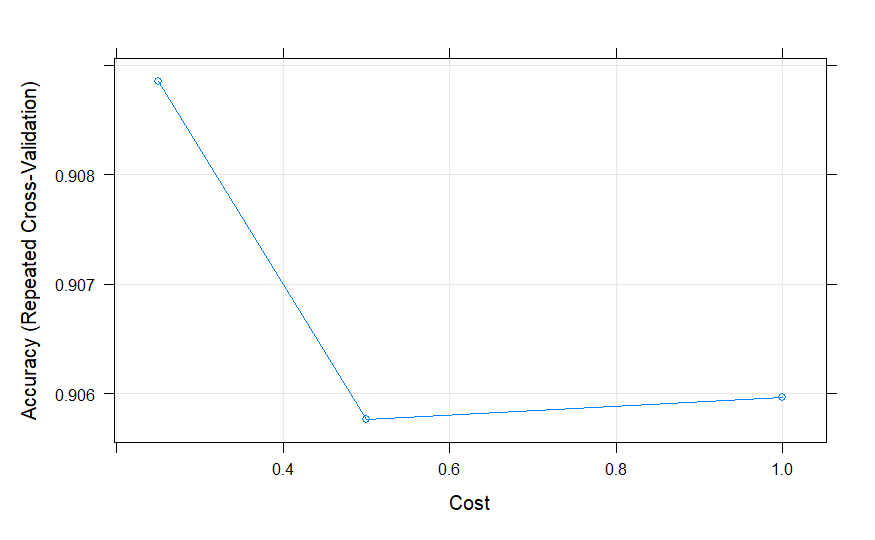

```r
plot(svm_lin_clf)
```

Perform hyperparameter tuning using `tuneGrid`.

```r
svm_lin_tuneGrid <- expand.grid(cost = seq(0.05, 0.5, 0.05))

svm_lin_clf <- train_model("svmLinear2", tuneGrid = svm_lin_tuneGrid)
```

```
Support Vector Machines with Linear Kernel

520 samples
 32 predictor
  2 classes: 'fail', 'pass'

Pre-processing: centered (72), scaled (72)
Resampling: Cross-Validated (10 fold, repeated 10 times)
Summary of sample sizes: 468, 468, 468, 468, 468, 468, ...
Resampling results across tuning parameters:

  cost  Accuracy   Kappa
  0.05  0.9138462  0.6367530
  0.10  0.9167308  0.6605373
  0.15  0.9140385  0.6532029
  0.20  0.9115385  0.6491946
  0.25  0.9088462  0.6400712
  0.30  0.9073077  0.6336529
  0.35  0.9078846  0.6374562
  0.40  0.9061538  0.6336616
  0.45  0.9051923  0.6302050
  0.50  0.9057692  0.6324726

Accuracy was used to select the optimal model using the largest value.
The final value used for the model was cost = 0.1.
```

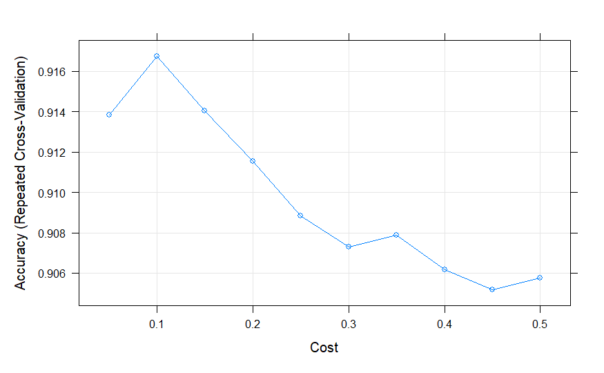

```r
plot(svm_lin_clf)
```

Tuning done.

```r
svm_lin_metrics <- evaluate_model(svm_lin_clf, "SVM - Linear", "SVM")
```

```
Confusion Matrix and Statistics

          Reference
Prediction fail pass
      fail   14    6
      pass    6  103

               Accuracy : 0.907
                 95% CI : (0.8431, 0.951)
    No Information Rate : 0.845
    P-Value [Acc > NIR] : 0.02831

                  Kappa : 0.645

 Mcnemar's Test P-Value : 1.00000

              Precision : 0.7000
                 Recall : 0.7000
                     F1 : 0.7000
             Prevalence : 0.1550
         Detection Rate : 0.1085
   Detection Prevalence : 0.1550
      Balanced Accuracy : 0.8225

       'Positive' Class : fail
```

##### Down-Sampled Train Set

```r
down_svm_lin_clf <- train_model("svmLinear2", down_train_set)
```

```
Support Vector Machines with Linear Kernel

160 samples
 32 predictor
  2 classes: 'fail', 'pass'

Pre-processing: centered (72), scaled (72)
Resampling: Cross-Validated (10 fold, repeated 10 times)
Summary of sample sizes: 144, 144, 144, 144, 144, 144, ...
Resampling results across tuning parameters:

  cost  Accuracy  Kappa
  0.25  0.756875  0.51375
  0.50  0.753750  0.50750
  1.00  0.750625  0.50125

Accuracy was used to select the optimal model using the largest value.
The final value used for the model was cost = 0.25.
```

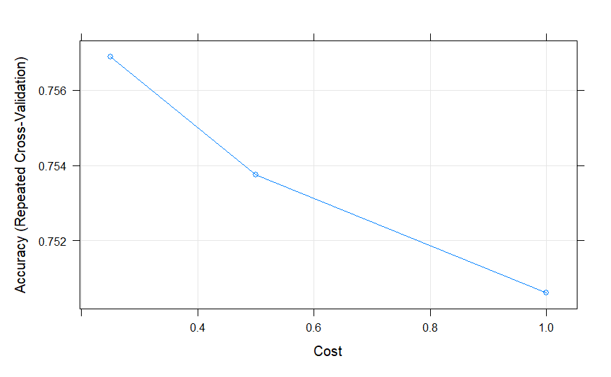

```r
plot(down_svm_lin_clf)
```

Perform hyperparameter tuning using `tuneGrid`.

```r
down_svm_lin_tuneGrid <- expand.grid(cost = seq(0.05, 0.5, 0.05))

down_svm_lin_clf <- train_model(
  "svmLinear2",
  down_train_set,
  tuneGrid = down_svm_lin_tuneGrid
)
```

```
Support Vector Machines with Linear Kernel

160 samples
 32 predictor
  2 classes: 'fail', 'pass'

Pre-processing: centered (72), scaled (72)
Resampling: Cross-Validated (10 fold, repeated 10 times)
Summary of sample sizes: 144, 144, 144, 144, 144, 144, ...
Resampling results across tuning parameters:

  cost  Accuracy  Kappa
  0.05  0.765625  0.53125
  0.10  0.766250  0.53250
  0.15  0.755625  0.51125
  0.20  0.753125  0.50625
  0.25  0.756875  0.51375
  0.30  0.758750  0.51750
  0.35  0.755000  0.51000
  0.40  0.755000  0.51000
  0.45  0.753750  0.50750
  0.50  0.753750  0.50750

Accuracy was used to select the optimal model using the largest value.
The final value used for the model was cost = 0.1.
```

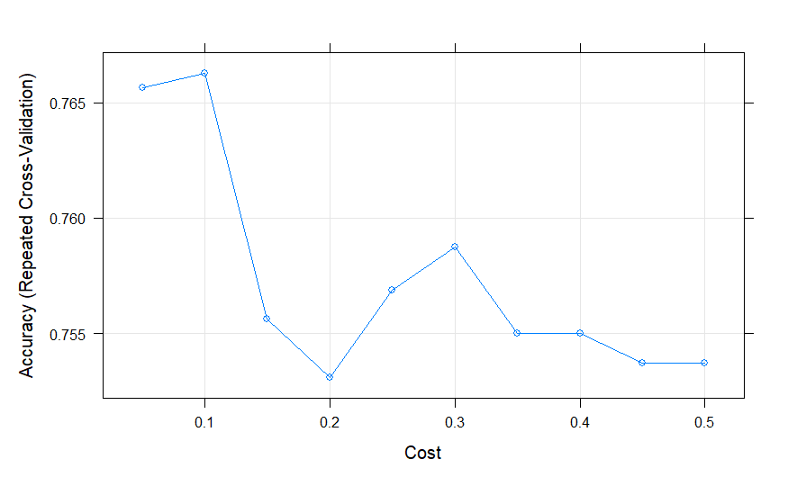

```r
plot(down_svm_lin_clf)
```

Tuning done.

```r
down_svm_lin_metrics <- evaluate_model(down_svm_lin_clf, "SVM - Linear", "SVM")
```

```
Confusion Matrix and Statistics

          Reference
Prediction fail pass
      fail   17   16
      pass    3   93

               Accuracy : 0.8527
                 95% CI : (0.7796, 0.9089)
    No Information Rate : 0.845
    P-Value [Acc > NIR] : 0.462672

                  Kappa : 0.5557

 Mcnemar's Test P-Value : 0.005905

              Precision : 0.5152
                 Recall : 0.8500
                     F1 : 0.6415
             Prevalence : 0.1550
         Detection Rate : 0.1318
   Detection Prevalence : 0.2558
      Balanced Accuracy : 0.8516

       'Positive' Class : fail
```

##### Up-Sampled Train Set

```r
up_svm_lin_clf <- train_model("svmLinear2", up_train_set)
```

```
Support Vector Machines with Linear Kernel

880 samples
 32 predictor
  2 classes: 'fail', 'pass'

Pre-processing: centered (72), scaled (72)
Resampling: Cross-Validated (10 fold, repeated 10 times)
Summary of sample sizes: 792, 792, 792, 792, 792, 792, ...
Resampling results across tuning parameters:

  cost  Accuracy   Kappa
  0.25  0.9523864  0.9047727
  0.50  0.9550000  0.9100000
  1.00  0.9584091  0.9168182

Accuracy was used to select the optimal model using the largest value.
The final value used for the model was cost = 1.
```

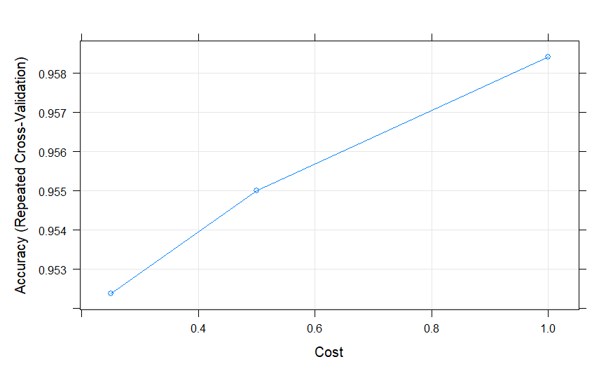

```r
plot(up_svm_lin_clf)
```

Perform hyperparameter tuning using `tuneLength`.

```r
up_svm_lin_clf <- train_model("svmLinear2", up_train_set, tuneLength = 10)
```

```
Support Vector Machines with Linear Kernel

880 samples
 32 predictor
  2 classes: 'fail', 'pass'

Pre-processing: centered (72), scaled (72)
Resampling: Cross-Validated (10 fold, repeated 10 times)
Summary of sample sizes: 792, 792, 792, 792, 792, 792, ...
Resampling results across tuning parameters:

  cost    Accuracy   Kappa
    0.25  0.9523864  0.9047727
    0.50  0.9550000  0.9100000
    1.00  0.9584091  0.9168182
    2.00  0.9577273  0.9154545
    4.00  0.9573864  0.9147727
    8.00  0.9576136  0.9152273
   16.00  0.9564773  0.9129545
   32.00  0.9557955  0.9115909
   64.00  0.9555682  0.9111364
  128.00  0.9555682  0.9111364

Accuracy was used to select the optimal model using the largest value.
The final value used for the model was cost = 1.
```

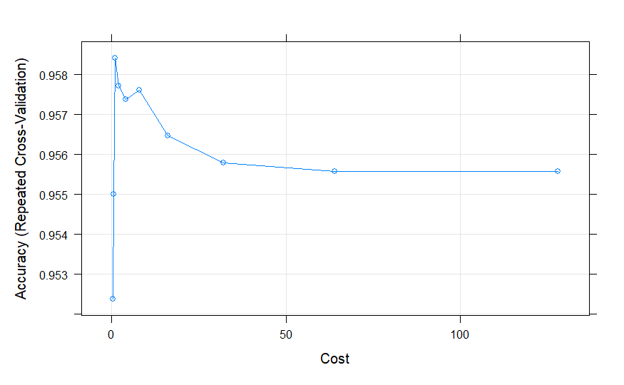

```r
plot(up_svm_lin_clf)
```

Tuning done.

```r
up_svm_lin_metrics <- evaluate_model(up_svm_lin_clf, "SVM - Linear", "SVM")
```

```
Confusion Matrix and Statistics

          Reference
Prediction fail pass
      fail   13    6
      pass    7  103

               Accuracy : 0.8992
                 95% CI : (0.8338, 0.9452)
    No Information Rate : 0.845
    P-Value [Acc > NIR] : 0.05125

                  Kappa : 0.6074

 Mcnemar's Test P-Value : 1.00000

              Precision : 0.6842
                 Recall : 0.6500
                     F1 : 0.6667
             Prevalence : 0.1550
         Detection Rate : 0.1008
   Detection Prevalence : 0.1473
      Balanced Accuracy : 0.7975

       'Positive' Class : fail
```

#### Support Vector Machine (Polynomial Kernel)

##### Original Train Set

```r
svm_poly_clf <- train_model("svmPoly")
```

```
Support Vector Machines with Polynomial Kernel

520 samples
 32 predictor
  2 classes: 'fail', 'pass'

Pre-processing: centered (72), scaled (72)
Resampling: Cross-Validated (10 fold, repeated 10 times)
Summary of sample sizes: 468, 468, 468, 468, 468, 468, ...
Resampling results across tuning parameters:

  degree  scale  C     Accuracy   Kappa
  1       0.001  0.25  0.8461538  0.000000000
  1       0.001  0.50  0.8461538  0.000000000
  1       0.001  1.00  0.8461538  0.000000000
```

[output cut: 27 more lines]

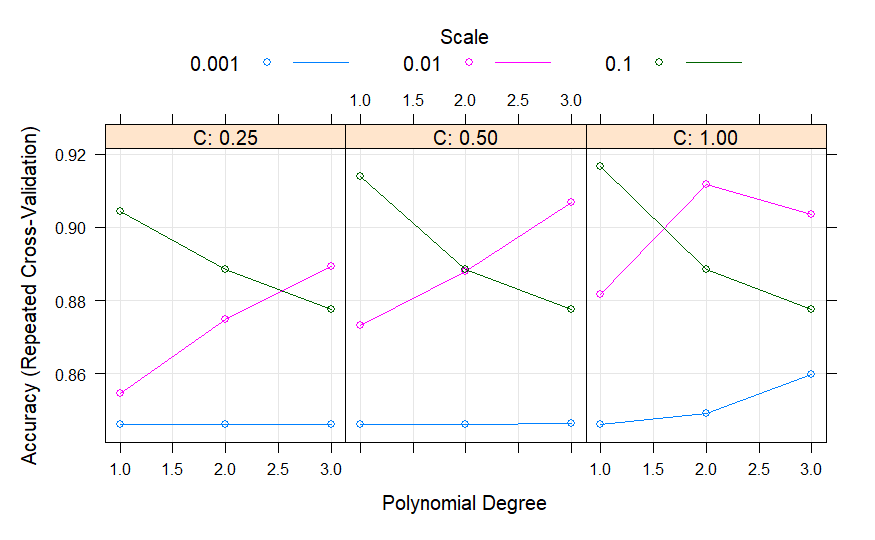

```r
plot(svm_poly_clf)
```

Perform hyperparameter tuning using `tuneGrid`.

```r
svm_poly_tuneGrid <- expand.grid(
  degree = 1,
  scale = c(0.01, 0.1),
  C = seq(0.1, 1.5, 0.05)
)

svm_poly_clf <- train_model("svmPoly", tuneGrid = svm_poly_tuneGrid)
```

```
Support Vector Machines with Polynomial Kernel

520 samples
 32 predictor
  2 classes: 'fail', 'pass'

Pre-processing: centered (72), scaled (72)
Resampling: Cross-Validated (10 fold, repeated 10 times)
Summary of sample sizes: 468, 468, 468, 468, 468, 468, ...
Resampling results across tuning parameters:

  scale  C     Accuracy   Kappa
  0.01   0.10  0.8461538  0.00000000
  0.01   0.15  0.8461538  0.00000000
  0.01   0.20  0.8492308  0.03086319
  0.01   0.25  0.8546154  0.08394023
  0.01   0.30  0.8576923  0.11365443
  0.01   0.35  0.8638462  0.17052312
  0.01   0.40  0.8682692  0.21034175
  0.01   0.45  0.8713462  0.24060396
  0.01   0.50  0.8732692  0.26059984
  0.01   0.55  0.8755769  0.28188147
  0.01   0.60  0.8753846  0.28132437
  0.01   0.65  0.8773077  0.29947793
  0.01   0.70  0.8782692  0.31299249
  0.01   0.75  0.8803846  0.33723638
  0.01   0.80  0.8819231  0.35690555
  0.01   0.85  0.8821154  0.36999562
  0.01   0.90  0.8826923  0.38047267
  0.01   0.95  0.8825000  0.39115441
  0.01   1.00  0.8817308  0.39497286
  0.01   1.05  0.8821154  0.40146122
  0.01   1.10  0.8838462  0.41961460
  0.01   1.15  0.8842308  0.42965830
  0.01   1.20  0.8853846  0.43706948
  0.01   1.25  0.8878846  0.45460578
  0.01   1.30  0.8900000  0.47114159
  0.01   1.35  0.8917308  0.48367835
  0.01   1.40  0.8919231  0.48581998
  0.01   1.45  0.8938462  0.50044125
```

[output cut: 19 more lines]

```
  0.10   1.00  0.9167308  0.66053735
  0.10   1.05  0.9163462  0.65870244
  0.10   1.10  0.9155769  0.65680728
  0.10   1.15  0.9161538  0.65811114
  0.10   1.20  0.9163462  0.65900978
  0.10   1.25  0.9167308  0.66071945
  0.10   1.30  0.9161538  0.65865021
  0.10   1.35  0.9155769  0.65711508
  0.10   1.40  0.9148077  0.65527095
  0.10   1.45  0.9140385  0.65206420
  0.10   1.50  0.9140385  0.65320292

Tuning parameter 'degree' was held constant at a value of 1
Accuracy was used to select the optimal model using the largest value.
The final values used for the model were degree = 1, scale = 0.1 and C = 0.7.
```

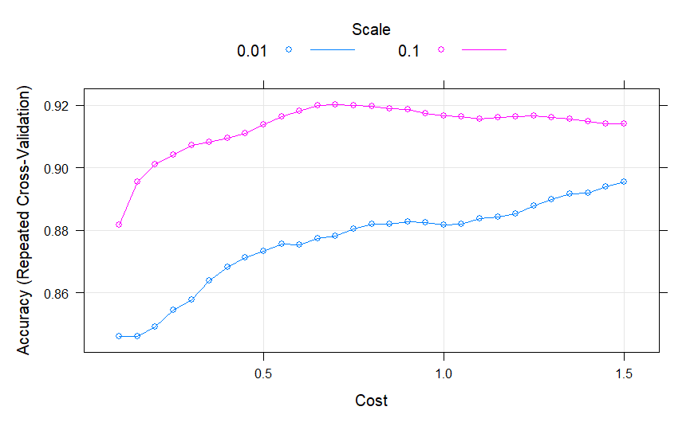

```r
plot(svm_poly_clf)
```

Tuning done.

```r
svm_poly_metrics <- evaluate_model(svm_poly_clf, "SVM - Poly", "SVM")
```

```
Confusion Matrix and Statistics

          Reference
Prediction fail pass
      fail   14    5
      pass    6  104

               Accuracy : 0.9147
                 95% CI : (0.8525, 0.9567)
    No Information Rate : 0.845
    P-Value [Acc > NIR] : 0.01442

                  Kappa : 0.6678

 Mcnemar's Test P-Value : 1.00000

              Precision : 0.7368
                 Recall : 0.7000
                     F1 : 0.7179
             Prevalence : 0.1550
         Detection Rate : 0.1085
   Detection Prevalence : 0.1473
      Balanced Accuracy : 0.8271

       'Positive' Class : fail
```

##### Down-Sampled Train Set

```r
down_svm_poly_clf <- train_model("svmPoly", down_train_set)
```

```
Support Vector Machines with Polynomial Kernel

160 samples
 32 predictor
  2 classes: 'fail', 'pass'

Pre-processing: centered (72), scaled (72)
Resampling: Cross-Validated (10 fold, repeated 10 times)
Summary of sample sizes: 144, 144, 144, 144, 144, 144, ...
Resampling results across tuning parameters:

  degree  scale  C     Accuracy  Kappa
  1       0.001  0.25  0.768750  0.53750
  1       0.001  0.50  0.768750  0.53750
  1       0.001  1.00  0.770000  0.54000
```

[output cut: 27 more lines]

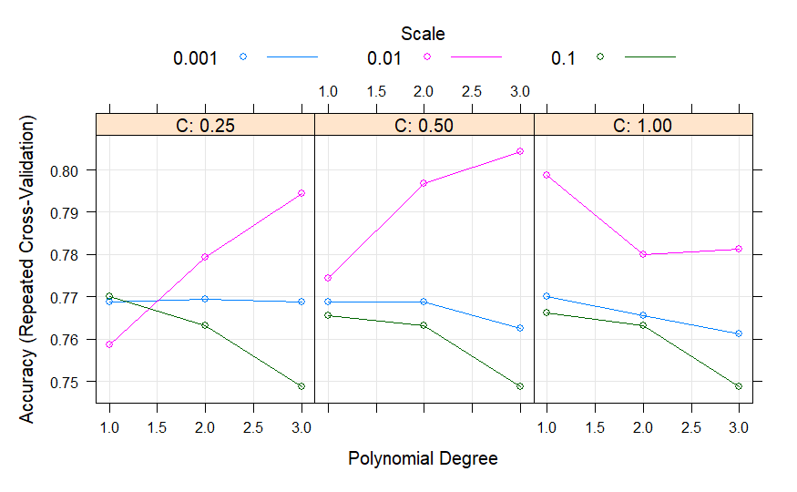

```r
plot(down_svm_poly_clf)
```

Perform hyperparameter tuning using `tuneGrid`.

```r
down_svm_poly_tuneGrid <- expand.grid(
  degree = 3,
  scale = 0.01,
  C = seq(0.25, 1, 0.05)
)

down_svm_poly_clf <- train_model(
  "svmPoly",
  down_train_set,
  tuneGrid = down_svm_poly_tuneGrid
)
```

```
Support Vector Machines with Polynomial Kernel

160 samples
 32 predictor
  2 classes: 'fail', 'pass'

Pre-processing: centered (72), scaled (72)
Resampling: Cross-Validated (10 fold, repeated 10 times)
Summary of sample sizes: 144, 144, 144, 144, 144, 144, ...
Resampling results across tuning parameters:

  C     Accuracy  Kappa
  0.25  0.794375  0.58875
  0.30  0.800000  0.60000
  0.35  0.801875  0.60375
  0.40  0.800625  0.60125
  0.45  0.802500  0.60500
  0.50  0.804375  0.60875
  0.55  0.801875  0.60375
  0.60  0.793125  0.58625
  0.65  0.795000  0.59000
  0.70  0.790625  0.58125
  0.75  0.788750  0.57750
  0.80  0.785000  0.57000
  0.85  0.784375  0.56875
  0.90  0.784375  0.56875
  0.95  0.781250  0.56250
  1.00  0.781250  0.56250

Tuning parameter 'degree' was held constant at a value of 3
Tuning
 parameter 'scale' was held constant at a value of 0.01
Accuracy was used to select the optimal model using the largest value.
The final values used for the model were degree = 3, scale = 0.01 and C = 0.5.
```

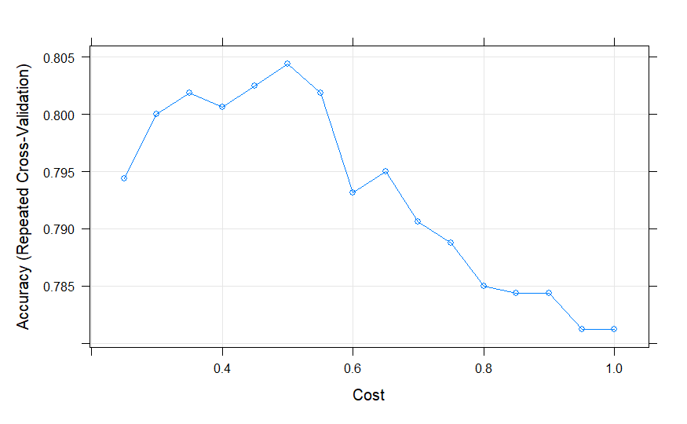

```r
plot(down_svm_poly_clf)
```

Tuning done.

```r
down_svm_poly_metrics <- evaluate_model(down_svm_poly_clf, "SVM - Poly", "SVM")
```

```
Confusion Matrix and Statistics

          Reference
Prediction fail pass
      fail   18   16
      pass    2   93

               Accuracy : 0.8605
                 95% CI : (0.7885, 0.9152)
    No Information Rate : 0.845
    P-Value [Acc > NIR] : 0.366920

                  Kappa : 0.5858

 Mcnemar's Test P-Value : 0.002183

              Precision : 0.5294
                 Recall : 0.9000
                     F1 : 0.6667
             Prevalence : 0.1550
         Detection Rate : 0.1395
   Detection Prevalence : 0.2636
      Balanced Accuracy : 0.8766

       'Positive' Class : fail
```

##### Up-Sampled Train Set

```r
up_svm_poly_clf <- train_model("svmPoly", up_train_set)
```

```
Support Vector Machines with Polynomial Kernel

880 samples
 32 predictor
  2 classes: 'fail', 'pass'

Pre-processing: centered (72), scaled (72)
Resampling: Cross-Validated (10 fold, repeated 10 times)
Summary of sample sizes: 792, 792, 792, 792, 792, 792, ...
Resampling results across tuning parameters:

  degree  scale  C     Accuracy   Kappa
  1       0.001  0.25  0.8207955  0.6415909
  1       0.001  0.50  0.8480682  0.6961364
  1       0.001  1.00  0.8709091  0.7418182
```

[output cut: 27 more lines]

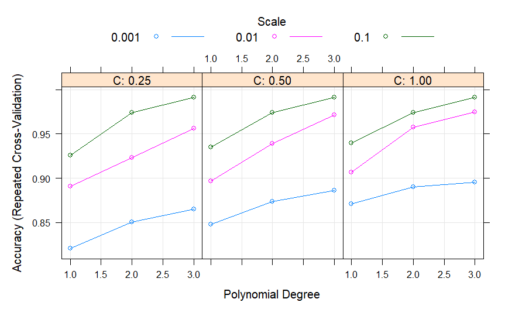

```r
plot(up_svm_poly_clf)
```

Perform hyperparameter tuning using `tuneGrid`.

```r
up_svm_poly_tuneGrid <- expand.grid(
  degree = 3,
  scale = 0.1,
  C = seq(0.05, 0.25, 0.05)
)

up_svm_poly_clf <- train_model(
  "svmPoly",
  up_train_set,
  tuneGrid = up_svm_poly_tuneGrid
)
```

```
Support Vector Machines with Polynomial Kernel

880 samples
 32 predictor
  2 classes: 'fail', 'pass'

Pre-processing: centered (72), scaled (72)
Resampling: Cross-Validated (10 fold, repeated 10 times)
Summary of sample sizes: 792, 792, 792, 792, 792, 792, ...
Resampling results across tuning parameters:

  C     Accuracy   Kappa
  0.05  0.9913636  0.9827273
  0.10  0.9913636  0.9827273
  0.15  0.9913636  0.9827273
  0.20  0.9913636  0.9827273
  0.25  0.9913636  0.9827273

Tuning parameter 'degree' was held constant at a value of 3
Tuning
 parameter 'scale' was held constant at a value of 0.1
Accuracy was used to select the optimal model using the largest value.
The final values used for the model were degree = 3, scale = 0.1 and C = 0.05.
```

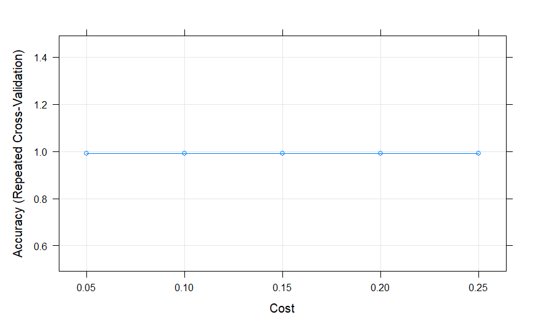

```r
plot(up_svm_poly_clf)
```

Tuning done.

```r
up_svm_poly_metrics <- evaluate_model(up_svm_poly_clf, "SVM - Poly", "SVM")
```

```
Confusion Matrix and Statistics

          Reference
Prediction fail pass
      fail    7    1
      pass   13  108

               Accuracy : 0.8915
                 95% CI : (0.8246, 0.9394)
    No Information Rate : 0.845
    P-Value [Acc > NIR] : 0.086135

                  Kappa : 0.4514

 Mcnemar's Test P-Value : 0.003283

              Precision : 0.87500
                 Recall : 0.35000
                     F1 : 0.50000
             Prevalence : 0.15504
         Detection Rate : 0.05426
   Detection Prevalence : 0.06202
      Balanced Accuracy : 0.67041

       'Positive' Class : fail
```

#### Support Vector Machine (Radial Basis Function Kernel)

##### Original Train Set

```r
svm_rbf_clf <- train_model("svmRadial")
```

```
Support Vector Machines with Radial Basis Function Kernel

520 samples
 32 predictor
  2 classes: 'fail', 'pass'

Pre-processing: centered (72), scaled (72)
Resampling: Cross-Validated (10 fold, repeated 10 times)
Summary of sample sizes: 468, 468, 468, 468, 468, 468, ...
Resampling results across tuning parameters:

  C     Accuracy   Kappa
  0.25  0.8461538  0.00000000
  0.50  0.8557692  0.09504715
  1.00  0.8821154  0.34626083

Tuning parameter 'sigma' was held constant at a value of 0.007521361
Accuracy was used to select the optimal model using the largest value.
The final values used for the model were sigma = 0.007521361 and C = 1.
```

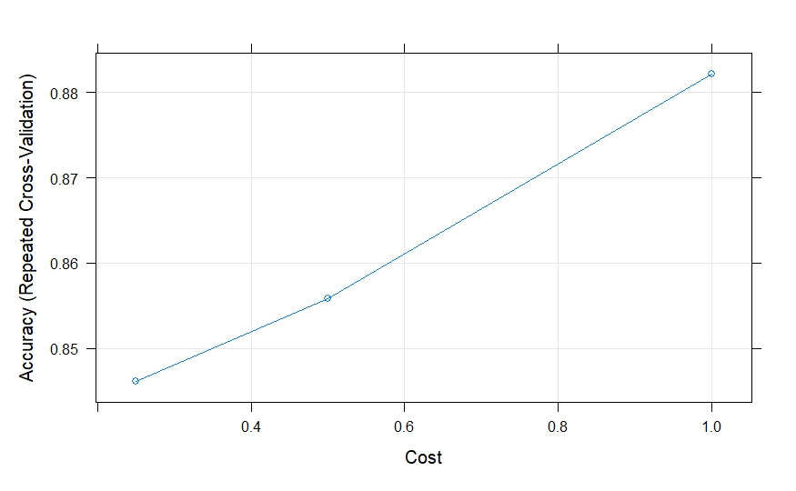

```r
plot(svm_rbf_clf)
```

Perform hyperparameter tuning using `tuneLength`.

```r
svm_rbf_clf <- train_model("svmRadial", tuneLength = 7)
```

```
Support Vector Machines with Radial Basis Function Kernel

520 samples
 32 predictor
  2 classes: 'fail', 'pass'

Pre-processing: centered (72), scaled (72)
Resampling: Cross-Validated (10 fold, repeated 10 times)
Summary of sample sizes: 468, 468, 468, 468, 468, 468, ...
Resampling results across tuning parameters:

  C      Accuracy   Kappa
   0.25  0.8461538  0.00000000
   0.50  0.8557692  0.09504715
   1.00  0.8821154  0.34626083
   2.00  0.8913462  0.48528969
   4.00  0.9021154  0.57154032
   8.00  0.9003846  0.56889460
  16.00  0.9003846  0.56839398

Tuning parameter 'sigma' was held constant at a value of 0.007521361
Accuracy was used to select the optimal model using the largest value.
The final values used for the model were sigma = 0.007521361 and C = 4.
```

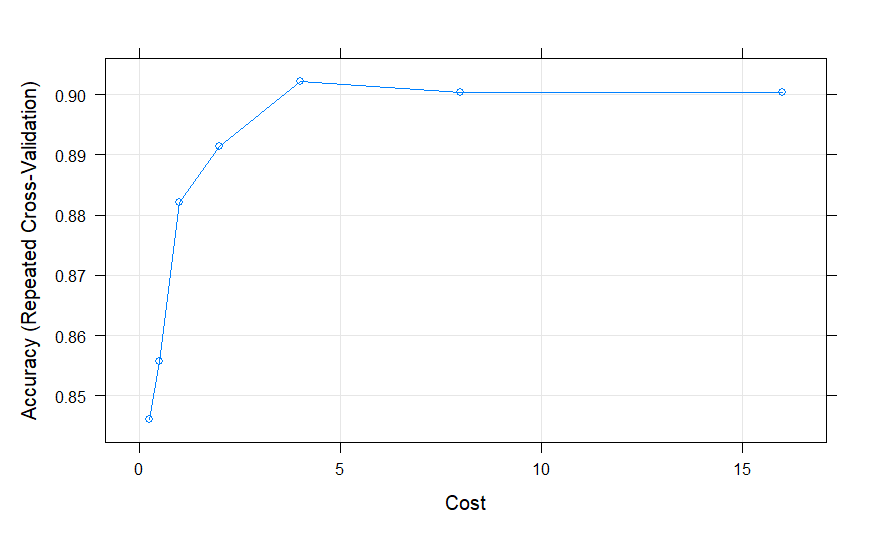

```r
plot(svm_rbf_clf)
```

Tuning done.

```r
svm_rbf_metrics <- evaluate_model(svm_rbf_clf, "SVM - RBF", "SVM")
```

```
Confusion Matrix and Statistics

          Reference
Prediction fail pass
      fail   11    5
      pass    9  104

               Accuracy : 0.8915
                 95% CI : (0.8246, 0.9394)
    No Information Rate : 0.845
    P-Value [Acc > NIR] : 0.08614

                  Kappa : 0.549

 Mcnemar's Test P-Value : 0.42268

              Precision : 0.68750
                 Recall : 0.55000
                     F1 : 0.61111
             Prevalence : 0.15504
         Detection Rate : 0.08527
   Detection Prevalence : 0.12403
      Balanced Accuracy : 0.75206

       'Positive' Class : fail
```

##### Down-Sampled Train Set

```r
down_svm_rbf_clf <- train_model("svmRadial", down_train_set)
```

```
Support Vector Machines with Radial Basis Function Kernel

160 samples
 32 predictor
  2 classes: 'fail', 'pass'

Pre-processing: centered (72), scaled (72)
Resampling: Cross-Validated (10 fold, repeated 10 times)
Summary of sample sizes: 144, 144, 144, 144, 144, 144, ...
Resampling results across tuning parameters:

  C     Accuracy  Kappa
  0.25  0.76500   0.5300
  0.50  0.76375   0.5275
  1.00  0.78000   0.5600

Tuning parameter 'sigma' was held constant at a value of 0.007491754
Accuracy was used to select the optimal model using the largest value.
The final values used for the model were sigma = 0.007491754 and C = 1.
```

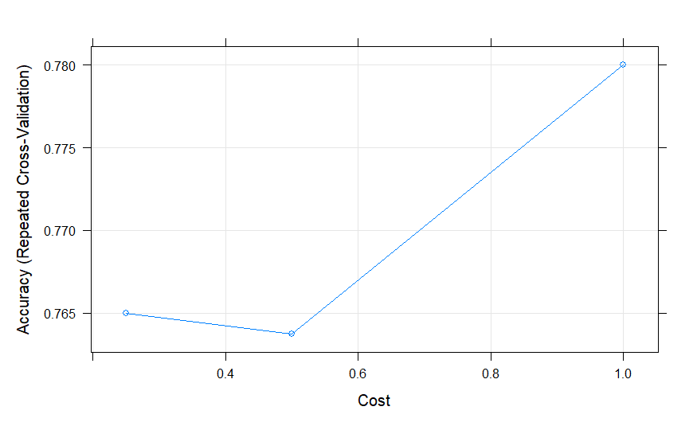

```r
plot(down_svm_rbf_clf)
```

Perform hyperparameter tuning using `tuneLength`.

```r
down_svm_rbf_clf <- train_model("svmRadial", down_train_set, tuneLength = 7)
```

```
Support Vector Machines with Radial Basis Function Kernel

160 samples
 32 predictor
  2 classes: 'fail', 'pass'

Pre-processing: centered (72), scaled (72)
Resampling: Cross-Validated (10 fold, repeated 10 times)
Summary of sample sizes: 144, 144, 144, 144, 144, 144, ...
Resampling results across tuning parameters:

  C      Accuracy  Kappa
   0.25  0.765000  0.53000
   0.50  0.763750  0.52750
   1.00  0.780000  0.56000
   2.00  0.788125  0.57625
   4.00  0.788125  0.57625
   8.00  0.785000  0.57000
  16.00  0.785000  0.57000

Tuning parameter 'sigma' was held constant at a value of 0.007491754
Accuracy was used to select the optimal model using the largest value.
The final values used for the model were sigma = 0.007491754 and C = 2.
```

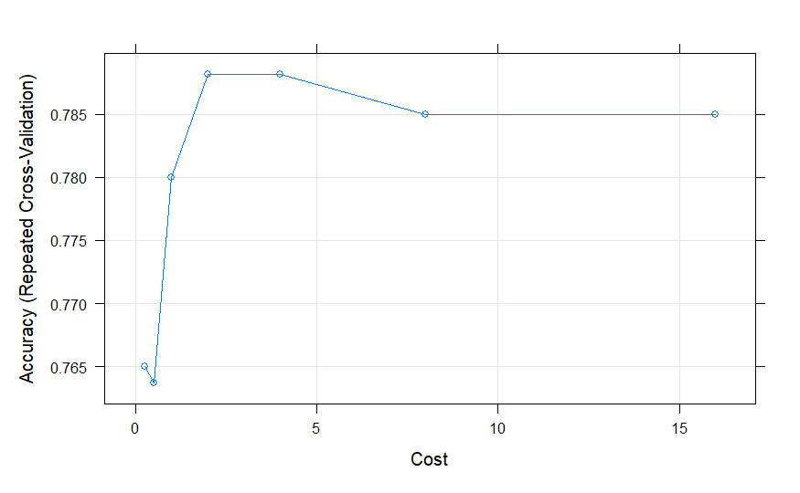

```r
plot(down_svm_rbf_clf)
```

Tuning done.

```r
down_svm_rbf_metrics <- evaluate_model(down_svm_rbf_clf, "SVM - RBF", "SVM")
```

```
Confusion Matrix and Statistics

          Reference
Prediction fail pass
      fail   18   16
      pass    2   93

               Accuracy : 0.8605
                 95% CI : (0.7885, 0.9152)
    No Information Rate : 0.845
    P-Value [Acc > NIR] : 0.366920

                  Kappa : 0.5858

 Mcnemar's Test P-Value : 0.002183

              Precision : 0.5294
                 Recall : 0.9000
                     F1 : 0.6667
             Prevalence : 0.1550
         Detection Rate : 0.1395
   Detection Prevalence : 0.2636
      Balanced Accuracy : 0.8766

       'Positive' Class : fail
```

##### Up-Sampled Train Set

```r
up_svm_rbf_clf <- train_model("svmRadial", up_train_set)
```

```
Support Vector Machines with Radial Basis Function Kernel

880 samples
 32 predictor
  2 classes: 'fail', 'pass'

Pre-processing: centered (72), scaled (72)
Resampling: Cross-Validated (10 fold, repeated 10 times)
Summary of sample sizes: 792, 792, 792, 792, 792, 792, ...
Resampling results across tuning parameters:

  C     Accuracy   Kappa
  0.25  0.9010227  0.8020455
  0.50  0.9218182  0.8436364
  1.00  0.9406818  0.8813636

Tuning parameter 'sigma' was held constant at a value of 0.007434027
Accuracy was used to select the optimal model using the largest value.
The final values used for the model were sigma = 0.007434027 and C = 1.
```

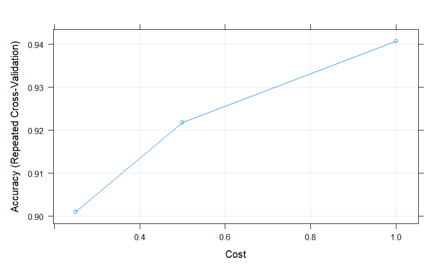

```r
plot(up_svm_rbf_clf)
```

Perform hyperparameter tuning using `tuneLength`.

```r
up_svm_rbf_clf <- train_model("svmRadial", up_train_set, tuneLength = 10)
```

```
Support Vector Machines with Radial Basis Function Kernel

880 samples
 32 predictor
  2 classes: 'fail', 'pass'

Pre-processing: centered (72), scaled (72)
Resampling: Cross-Validated (10 fold, repeated 10 times)
Summary of sample sizes: 792, 792, 792, 792, 792, 792, ...
Resampling results across tuning parameters:

  C       Accuracy   Kappa
    0.25  0.9010227  0.8020455
    0.50  0.9218182  0.8436364
    1.00  0.9406818  0.8813636
    2.00  0.9629545  0.9259091
    4.00  0.9737500  0.9475000
    8.00  0.9754545  0.9509091
   16.00  0.9756818  0.9513636
   32.00  0.9756818  0.9513636
   64.00  0.9756818  0.9513636
  128.00  0.9756818  0.9513636

Tuning parameter 'sigma' was held constant at a value of 0.007434027
Accuracy was used to select the optimal model using the largest value.
The final values used for the model were sigma = 0.007434027 and C = 16.
```

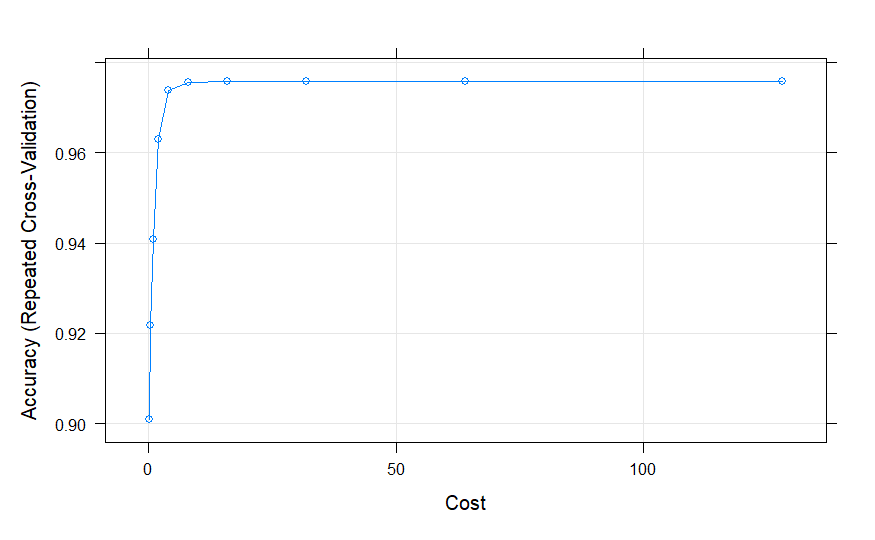

```r
plot(up_svm_rbf_clf)
```

Tuning done.

```r
up_svm_rbf_metrics <- evaluate_model(up_svm_rbf_clf, "SVM - RBF", "SVM")
```

```
Confusion Matrix and Statistics

          Reference
Prediction fail pass
      fail   12    5
      pass    8  104

               Accuracy : 0.8992
                 95% CI : (0.8338, 0.9452)
    No Information Rate : 0.845
    P-Value [Acc > NIR] : 0.05125

                  Kappa : 0.5903

 Mcnemar's Test P-Value : 0.57910

              Precision : 0.70588
                 Recall : 0.60000
                     F1 : 0.64865
             Prevalence : 0.15504
         Detection Rate : 0.09302
   Detection Prevalence : 0.13178
      Balanced Accuracy : 0.77706

       'Positive' Class : fail
```

#### Naive Bayes

##### Original Train Set

```r
nb_clf <- train_model("naive_bayes")
```

```
Naive Bayes

520 samples
 32 predictor
  2 classes: 'fail', 'pass'

Pre-processing: centered (72), scaled (72)
Resampling: Cross-Validated (10 fold, repeated 10 times)
Summary of sample sizes: 468, 468, 468, 468, 468, 468, ...
Resampling results across tuning parameters:

  usekernel  Accuracy   Kappa
  FALSE      0.8344231  0.4741662
   TRUE      0.7155769  0.3158678

Tuning parameter 'laplace' was held constant at a value of 0
Tuning
 parameter 'adjust' was held constant at a value of 1
Accuracy was used to select the optimal model using the largest value.
The final values used for the model were laplace = 0, usekernel = FALSE
 and adjust = 1.
```

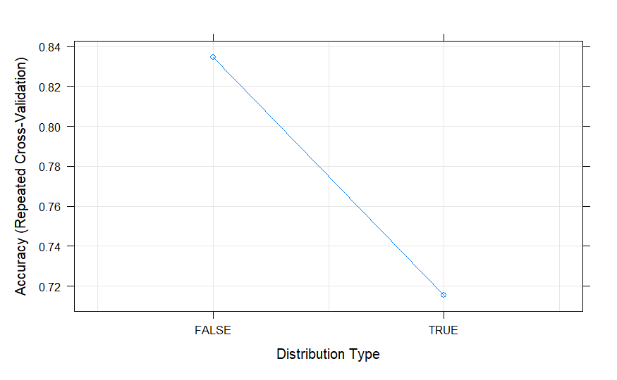

```r
plot(nb_clf)
```

Perform hyperparameter tuning using `tuneGrid`.

```r
nb_tuneGrid <- expand.grid(
  adjust = 1,
  usekernel = FALSE,
  laplace = seq(0, 1, 0.1)
)

nb_clf <- train_model("naive_bayes", tuneGrid = nb_tuneGrid)
```

```
Naive Bayes

520 samples
 32 predictor
  2 classes: 'fail', 'pass'

Pre-processing: centered (72), scaled (72)
Resampling: Cross-Validated (10 fold, repeated 10 times)
Summary of sample sizes: 468, 468, 468, 468, 468, 468, ...
Resampling results across tuning parameters:

  laplace  Accuracy   Kappa
  0.0      0.8344231  0.4741662
  0.1      0.8344231  0.4741662
  0.2      0.8344231  0.4741662
  0.3      0.8344231  0.4741662
  0.4      0.8344231  0.4741662
  0.5      0.8344231  0.4741662
  0.6      0.8344231  0.4741662
  0.7      0.8344231  0.4741662
  0.8      0.8344231  0.4741662
  0.9      0.8344231  0.4741662
  1.0      0.8344231  0.4741662

Tuning parameter 'usekernel' was held constant at a value of FALSE

Tuning parameter 'adjust' was held constant at a value of 1
Accuracy was used to select the optimal model using the largest value.
The final values used for the model were laplace = 0, usekernel = FALSE
 and adjust = 1.
```

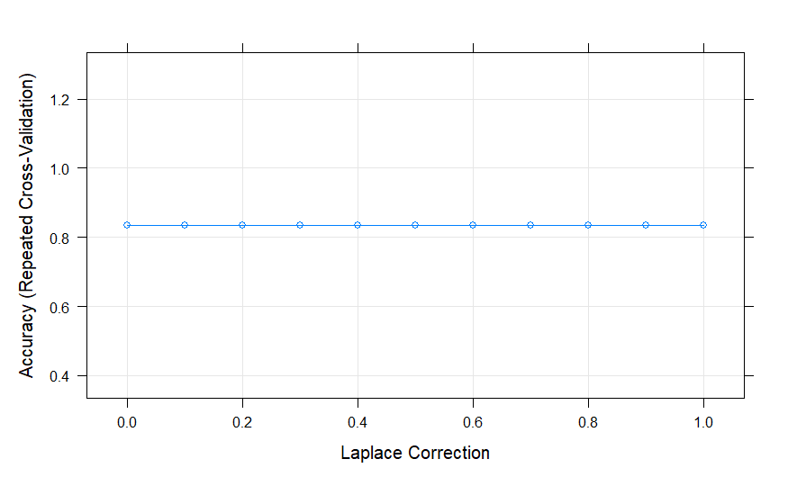

```r
plot(nb_clf)
```

Tuning done.

```r
nb_metrics <- evaluate_model(nb_clf, "NB")
```

```
Confusion Matrix and Statistics

          Reference
Prediction fail pass
      fail   17   18
      pass    3   91

               Accuracy : 0.8372
                 95% CI : (0.762, 0.8963)
    No Information Rate : 0.845
    P-Value [Acc > NIR] : 0.65133

                  Kappa : 0.5243

 Mcnemar's Test P-Value : 0.00225

              Precision : 0.4857
                 Recall : 0.8500
                     F1 : 0.6182
             Prevalence : 0.1550
         Detection Rate : 0.1318
   Detection Prevalence : 0.2713
      Balanced Accuracy : 0.8424

       'Positive' Class : fail
```

##### Down-Sampled Train Set

```r
down_nb_clf <- train_model("naive_bayes", down_train_set)
```

```
Naive Bayes

160 samples
 32 predictor
  2 classes: 'fail', 'pass'

Pre-processing: centered (72), scaled (72)
Resampling: Cross-Validated (10 fold, repeated 10 times)
Summary of sample sizes: 144, 144, 144, 144, 144, 144, ...
Resampling results across tuning parameters:

  usekernel  Accuracy  Kappa
  FALSE      0.761250  0.52250
   TRUE      0.531875  0.06375

Tuning parameter 'laplace' was held constant at a value of 0
Tuning
 parameter 'adjust' was held constant at a value of 1
Accuracy was used to select the optimal model using the largest value.
The final values used for the model were laplace = 0, usekernel = FALSE
 and adjust = 1.
```

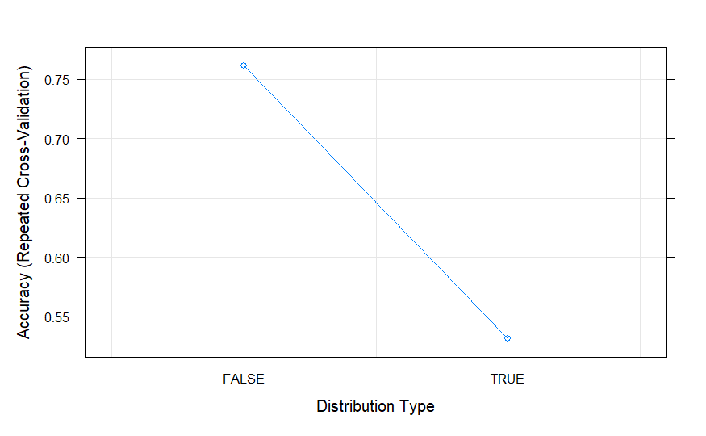

```r
plot(down_nb_clf)
```

Perform hyperparameter tuning using `tuneGrid`.

```r
down_nb_tuneGrid <- expand.grid(
  adjust = 1,
  usekernel = FALSE,
  laplace = seq(0, 1, 0.1)
)

down_nb_clf <- train_model(
  "naive_bayes",
  down_train_set,
  tuneGrid = down_nb_tuneGrid
)
```

```
Naive Bayes

160 samples
 32 predictor
  2 classes: 'fail', 'pass'

Pre-processing: centered (72), scaled (72)
Resampling: Cross-Validated (10 fold, repeated 10 times)
Summary of sample sizes: 144, 144, 144, 144, 144, 144, ...
Resampling results across tuning parameters:

  laplace  Accuracy  Kappa
  0.0      0.76125   0.5225
  0.1      0.76125   0.5225
  0.2      0.76125   0.5225
  0.3      0.76125   0.5225
  0.4      0.76125   0.5225
  0.5      0.76125   0.5225
  0.6      0.76125   0.5225
  0.7      0.76125   0.5225
  0.8      0.76125   0.5225
  0.9      0.76125   0.5225
  1.0      0.76125   0.5225

Tuning parameter 'usekernel' was held constant at a value of FALSE

Tuning parameter 'adjust' was held constant at a value of 1
Accuracy was used to select the optimal model using the largest value.
The final values used for the model were laplace = 0, usekernel = FALSE
 and adjust = 1.
```

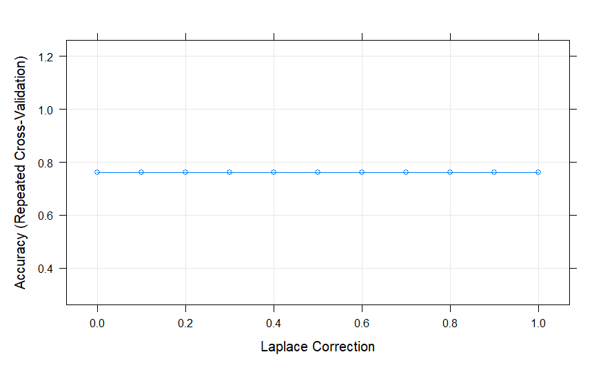

```r
plot(down_nb_clf)
```

Tuning done.

```r
down_nb_metrics <- evaluate_model(down_nb_clf, "NB")
```

```
Confusion Matrix and Statistics

          Reference
Prediction fail pass
      fail   17   20
      pass    3   89

               Accuracy : 0.8217
                 95% CI : (0.7446, 0.8835)
    No Information Rate : 0.845
    P-Value [Acc > NIR] : 0.8049881

                  Kappa : 0.4948

 Mcnemar's Test P-Value : 0.0008492

              Precision : 0.4595
                 Recall : 0.8500
                     F1 : 0.5965
             Prevalence : 0.1550
         Detection Rate : 0.1318
   Detection Prevalence : 0.2868
      Balanced Accuracy : 0.8333

       'Positive' Class : fail
```